# Validating a bike network analysis score based on open data as a connectivity measure of urban cycling infrastructure

Thesis Proposal

Lorena Abad

November 12, 2018

**Previous title:** Optimizing connectivity of urban cycling infrastructure through a bike network analysis score based on open data

## Introduction

Sustainable mobility has been one of the many strategies adopted by cities to tackle climate change (Banister 2011) and improve the living conditions of their inhabitants. There is no doubt that non-motorized transport has long been the most obvious and easiest mean to implement. Walking and cycling are not only a way to improve our environment, by decreasing air pollution and energy consumption (Fraser and Lock 2011); but also ameliorate citizens health (Hartog et al. 2010), reduce traffic jams, and reactivate public spaces. Therefore, investing in cycling and pedestrian infrastructure becomes a vital axis of transportation policies in metropolitan areas.

Nevertheless, finding an optimal way to plan this cycling infrastructure is still a challenge, especially for cities that are just starting. Several measures and tools have been created (Twadell et al. 2018) to evaluate such infrastructure in different cities, however they usually lack a proper validation on the places where they are applied.

### Previous work

During the first semester I worked together with Luuk van der Meer for the Group Project Seminar focused on python for GIS on a project entitled “Bicycle Network Analysis for the city of Lisbon”. The project consisted on developing a Bicycle Network Analysis score that allowed a quantification of the biking network and infrastructure status in Lisbon based on open data. To do so, we analyzed the segments of the existing bike network in Lisbon based on OpenStreetMap, and classified them according to their level of traffic stress into low and high stress segments (Fig. 1 on the left). Then, we evaluated how well the low stress network connected the cyclists within a biking distance of 6 km to core services like schools, universities, supermarkets, etc., based on an hexagonal grid, where each cell was assigned a value for their connectivity capability from 0 to 100 (Fig. 1 on the right).

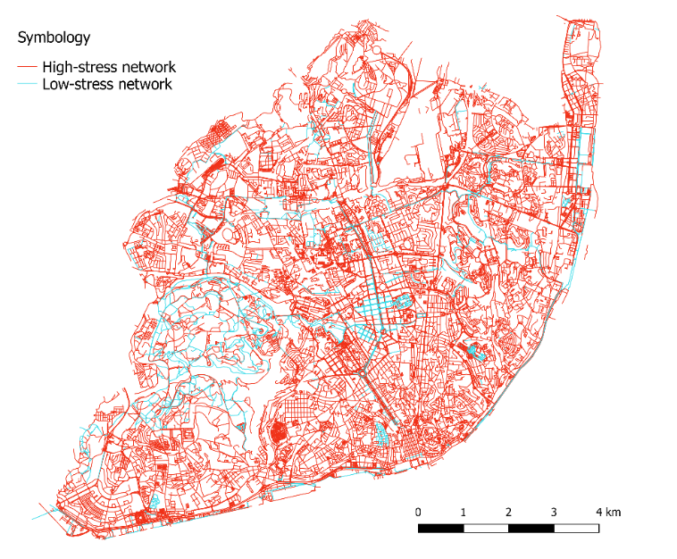

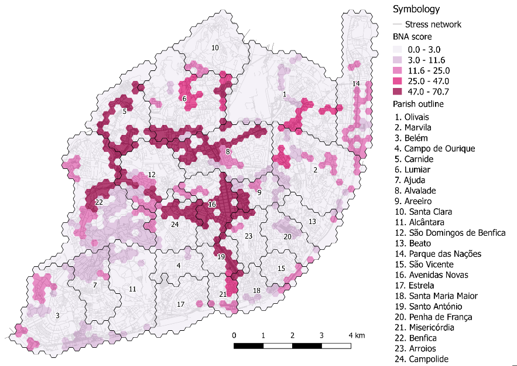

**Fig. 1:** Stress network and BNA score results for Lisbon.

The resulting low-stress network was very limited according to the classification criteria. Only 9% out of the 42,294 analyzed segments were classified as low-stress. Finally, an overall BNA score for the city of Lisbon was calculated, based on a weighted average according to the population fraction corresponding to each cell, with a result of 8.6 out of 100 points. The developed tool showed how the use of open data, even with its limitations, can provide a quantification index of sustainable mobility for a city.

### Proposed work from initial limitations and suggestions

The mentioned analysis results were mainly limited by the fact that the intersections could not be included within the classification criteria for traffic stress level. This was mainly due to the time constraint that we had to develop the project, and therefore would be important to be included on future work to provide a better understanding of the network strengths and weaknesses.

Additionally, the final report was submitted as a short paper to the [Open Data for Open Cities](http://opendata4opencities.uji.es/agendalund/) Second edition of AGILE 2018 Workshop in Lund, Sweden. This lead to an article that can be accessed [here](https://www.mdpi.com/2078-2489/9/11/287). From the workshop participants suggestions a paper, currently in revision, was drafted, mentioning the following future work:

- Analyze thoroughly the set up of street networks to include segments and intersections altogether, as the PeopleForBikes approach considers, in an effort to translate the score for cities in Europe, considering the data limitations and possible replacements or, even further, modifications to the way the BNA score is calculated, given the available data.
- Build a validation procedure for the BNA score in Europe, in a way that the score is not only consider as an exploratory index, but as a trustful tool for urban planners to optimize the current bike network connectivity in cities, by including scenarios of potential low-stress segments locations within the bike network, and observing the enhancement of the BNA score as new bike infrastructure is being planned.

Taking into account the limitations and future work mentioned, asn consider the latter is quite ambicious for the timeframe of the masters thesis, I decided to take up a part of the future work, coming up with the following research question: *How accurately can a quantitative index based on open and/or crowdsourced data serve as a tool to evaluate connectivity of low-stress cycling networks?*

### Aim and objectives

The research question derived into the aim of the research which is to develop a methodology to validate a bicycle network analysis score based on open data as a connectivity measure of urban cycling infrastructure. To do so I have established the following objectives:

- Improve the classification methodology previously developed for street segments (edges) and including also intersections (nodes) conforming the street network of a city into levels of traffic stress based on OpenStreetMap layers, tags, and additional ancillary data.
- Translate the current bicycle network analysis score scripting into an R and SQL based tool that would allow the computation of the score in European and USA cities.
- Establish a methodology to validate the capacity of such bicycle network analysis score to measure connectivity in the United Kingdom making use of their Origin-Destination data available at Middle Super Output Level (MSOA).
- Apply the validation schema and evaluate the capacity of the bicycle network analysis score to measure connectivity, creating a validation framework for European and USA cities which count with the sufficient open data available to implement it.

## Proposed methodology

This section includes a description of the background work on which the first part of the research was performed, the approach that this research will take, and the data it will based on.

### PfB approach

Bicycle network analyses have been undertaken from several angles making use of GIS tools. A recurrent approach within the literature is the level of traffic stress (LTS). Mekuria, Furth, and Nixon (2012), proposed a scheme to classify the road segments in four LTS, ranging from 1 - the level suitable for children - to 4 - the level tolerated by the “strong and fearless” cyclists. Their approach includes an analysis of the network connectivity with a thorough review of every segment and crossing, allowing an integral characterization of the bike network and assigning each section a stress level.

The [PeopleForBikes](https://peopleforbikes.org/) (PfB) organization developed a Bike Network Analysis (BNA), based on slightly modified LTS, to determine how people could get to common destinations on a comfortable and connected bike network (PeopleForBikes 2014). Their application targets USA cities and towns, basing their analysis mainly on OpenStreetMap data.

A scoring system, named BNA score, is developed by PfB, defining whether a bike-commuter can reach a destination census block (smallest administrative unit for the US) and main destination points within a biking distance of 10 minutes, computing the total number of destinations accessible with a low-stress bike network from an origin census block. A scoring scale between 0 and 100 is assigned to each destination type, on a stepped manner. Finally, the score is aggregated for the whole area in a weighted averaged fashion.

This thesis aims to translate their tool into an R and SQL based workflow, that can also be used in European cities and that validates the original BNA score underlying methodology to measure connectivity of urban cycling infrastructures. This validation will be focused on the UK given their abundant censal data, not only regarding demographic variables but also employment, and commuting information.

### Data

The main source of information to calculate the BNA score is OpenStreetMap (OSM) and basic demographic statistics of a city, usually provided as open data. The [OSM](https://www.openstreetmap.org/) data provides information regarding the street network of the city, including as well the [OpenCycleMap](https://www.opencyclemap.org/) information for the available cycleways; and the main destinations types including supermarkets, retail markets, schools, colleges, universities, hospitals, clinics, doctors, dentists, among others.

The demographic information relies basically on population data, which is usually available as open data for several levels of administrative units for the city to be evaluated. Employment information is a data set that is not always available in every city, however for the UK case, it is available within their [UK labour market datasets](https://www.ons.gov.uk/employmentandlabourmarket/peopleinwork/employmentandemployeetypes/bulletins/uklabourmarket/october2018).

Finally, [origin-destination data](https://www.nomisweb.co.uk/census/2011/wu03ew) for the UK at MSOA level, that will be used to evaluate the scoring procedure that the bycicle network analysis score follows, focusing on the Level of Traffic Stress classification, the destinations selection and weighting, and the overall BNA score compared to the total number of bicycle trips in the study areas.

## References

Banister, David. 2011. “Cities, mobility and climate change.” *Journal of Transport Geography* 19 (6). Elsevier Ltd: 1538–46. https://doi.org/10.1016/j.jtrangeo.2011.03.009.

Fraser, Simon D.S., and Karen Lock. 2011. “Cycling for transport and public health: A systematic review of the effect of the environment on cycling.” *European Journal of Public Health* 21 (6): 738–43. https://doi.org/10.1093/eurpub/ckq145.

Hartog, Jeroen Johan de, Hanna Boogaard, Hans Nijland, Gerard Hoek, Jeroen Johan de Hartog, Hanna Boogaard, Hans Nijland, and Gerard Hoek. 2010. “Do the health benefits of cycling outweigh the risks?” *Environmental Health Perspectives* 118 (8): 1109–16. https://doi.org/10.1289/ehp.0901747.

Mekuria, Maaza C, Peter G Furth, and Hilary Nixon. 2012. “Low-Stress Bicycling and Network Connectivity Low-Stress Bicycling and Network Connectivity.” San Jose, CA: Mineta Transportation Institute.

PeopleForBikes. 2014. “Methodology.” https://bna.peopleforbikes.org/#/methodology.

Twadell, Hannah, Elliot Rose, Joseph Broach, Jennifer Dill, Kelly Clifton, Claire Lust, Kimberly Voros, Hugh Louch, and Erin David. 2018. “Guidebook for Measuring Multimodal Network Connectivity.” February. Portland: Federal Highway Administration. https://www.fhwa.dot.gov/environment/bicycle_pedestrian/publications/multimodal_connectivity/.